# Visualización Interactiva en R

León Berdichevsky Acosta

## Shiny

### Introducción y Ejemplos

Shiny es una paquetería de R para construir aplicaciones web de manera sencilla directamente desde R. Shiny permite albergar aplicaciones directamente en una página web, incorporarlas a un documento de R Markdown o construir *dashboards*. También permite extender las aplicaciones con formatos de diseño gráfico CSS (*Cascading Style Sheets*), html *widgets* y acciones de Javascript.

Para instalar en R la paquetería de Shiny:

```r
install.packages("shiny")
```

La paquetería de Shiny contiene once ejemplos construidos que muestran cómo funciona Shiny. Comenzaremos con el ejemplo más sencillo:

El ejemplo **Hello** de Shiny grafica un histograma de la base de datos `faithful` con un número configurable de *bins*:

```r
library(shiny)
runExample("01_hello")
```

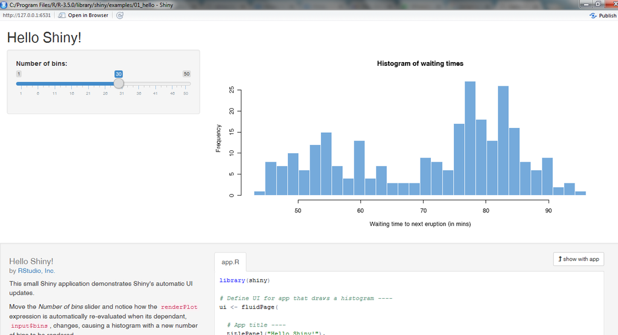

¿Cómo construimos la aplicación de este ejemplo?

Una aplicación de Shiny está contenida en un único *script* llamada `app.R`. Éste contiene 3 elementos:

1. Un **objeto** de interface de usuario `UI` (*user interface*).
2. Una **función** `server`.
3. Una referencia (**call**) a una función `shinyApp`.

Estos elementos funcionan como sigue:

1. El objeto `UI` controla la apariencia y el diseño gráfico de la aplicación.
2. La función `server` contiene las instrucciónes que la computadora necesita para construir la aplicación.
3. La función `shinyApp` crea el objeto en R a partir de los dos elementos anteriores.

Una ventaja de de tener una aplicación en un solo archivo `app.R` es que se torna muy sencillo compartir el código simplemente copiando y pegando todos los comandos en la consola de R.

Volviendo al ejemplo **Hello**:

1. El objeto `UI` se construye con el siguiente código:

```r
# Define UI for app that draws a histogram ----
ui <- fluidPage(
  # App title ----
  titlePanel("Hello Shiny!"),
  # Sidebar layout with input and output definitions ----
  sidebarLayout(
    # Sidebar panel for inputs ----
    sidebarPanel(
      # Input: Slider for the number of bins ----
      sliderInput(inputId = "bins",
                  label = "Number of bins:",
                  min = 1,
                  max = 50,
                  value = 30)
    ),
    # Main panel for displaying outputs ----
    mainPanel(
      # Output: Histogram ----
      plotOutput(outputId = "distPlot")
    )
  )
)
```

A grandes rasgos, la primera parte del código

```r
# Define UI for app that draws a histogram ----
ui <- fluidPage(
  # App title ----
  titlePanel("Hello Shiny!"),
```

hace referencia al título:

[figure not shown]

mientras que la segunda parte

```r
# Define UI for app that draws a histogram ----
ui <- fluidPage(...
  # Sidebar layout with input and output definitions ----
  sidebarLayout(...
  )
)
```

hace referencia al resto del diseño

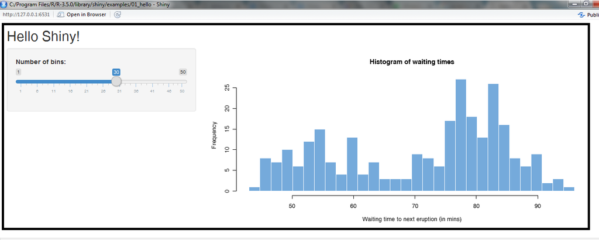

2. La función `server` en este caso es:

```r
server <- function(input, output) {
  # 1. It is "reactive" and therefore should be automatically
  # re-executed when inputs (input$bins) change
  # 2. Its output type is a plot
  output$distPlot <- renderPlot({
    x <- faithful$waiting
    bins <- seq(min(x), max(x), length.out = input$bins + 1)
    hist(x, breaks = bins, col = "#75AADB", border = "white",
      xlab = "Waiting time to next eruption (in mins)",
      main = "Histogram of waiting times")
  })
}
```

La función es relativamente simple: realiza ciertos cálculos y como *output* grafica un histograma con el número requerido de *bins*.

Explicaremos más adelante las diferentes funciones involucradas en `UI` y `server`.

3. Finalmente, es necesario crear el objeto (la aplicación) en R mediante la función `shinyApp`:

```r
shinyApp(ui = ui, server = server)
```

**Nota:** La sesión de R estará ejecutando la aplicación mientras ésta se encuentre abierta, mientras lo cual no es posible correr ningún otro comando en la consola. Para volver a la sesión de R es necesario cerrar la aplicación.

Es recomendado guardar cada archivo `app.R` de cada aplicación de Shiny en una carpeta diferente. De esta forma es posible correr la aplicación únicamente haciendo referencia a la carpeta correspondiente. Si la carpeta del ejemplo anterior se llama `Hello` y se encuentra en el directorio de trabajo (*working directory*), entonces el código para correr la aplicación es

```r
runApp("Hello")
```

o

```r
runApp("Hello", display.mode = "showcase")
```

**Pregunta:** ¿Cuál es la diferencia entre los dos comandos anteriores?

Una forma sencilla de crear otras aplicaciones es modificando los demás ejemplos existentes en la paquetería de Shiny:

```r
runExample("02_text")       # tables and data frames
runExample("03_reactivity") # a reactive expression
runExample("04_mpg")        # global variables
runExample("05_sliders")    # slider bars
runExample("06_tabsets")    # tabbed panels
runExample("07_widgets")    # help text and submit buttons
runExample("08_html")       # Shiny app built from HTML
runExample("09_upload")     # file upload wizard
runExample("10_download")   # file download wizard
runExample("11_timer")      # an automated timer
```

o las aplicaciones contruidas en la [galería](https://shiny.rstudio.com/gallery/) de Shiny.

### Interfaz y Diseño

El *script* más simple `app.R` que permite construir una aplicación de Shiny resulta en una aplicación vacía y se construye con el siguiente código:

```r
library(shiny)

# Define UI ----
ui <- fluidPage(
)

# Define server logic ----
server <- function(input, output) {
}

# Run the app ----
shinyApp(ui = ui, server = server)
```

Shiny utiliza la función `fluidPage` para crear un desplegado gráfico que se ajusta automáticamente a las dimensiones de la ventana del navegador en uso. La interfaz de la aplicación se despliega de acuerdo a elementos definidos dentro de esta función.

Por ejemplo, la siguiente `ui` crea una interfaz de usuario que contiene un título y un diseño de barra lateral que incluye un panel de barra laterial y un panel principal:

```r
ui <- fluidPage(
  titlePanel("title panel"),

  sidebarLayout(
    sidebarPanel("sidebar panel"),
    mainPanel("main panel")
  )
)
```

[figure not shown]

Los comandos `titlePanel` y `sidebarLayout` crean el diseño mas básico de una aplicación de Shiny. Otros diseños más avanzados se pueden encontrar en la [Application Layout Guide](https://shiny.rstudio.com/articles/layout-guide.html).

Para agregar contenido más avanzado, se pueden incluir las siguientes funciones HTML de Shiny dentro de los comandos `*Panel` (en el ejemplo anterior: `titlePanel`, `sidebarPanel` y `mainPanel`):

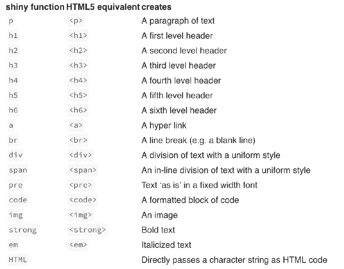

Estas funciones permiten incluir:

- Encabezados con varios niveles
- Texto en diferentes formatos
- Imágenes
- etc.

### Widgets de Control

Un **widget** es un elemento web con el que el usuario puede interactuar; provee un mecanismo mediante el cual el usuario envía mensajes a la aplicación.

Shiny incluye un conjunto de *widgets* que se pueden agregar a la aplicación mediante una función de R. Los *widgets* más comunes de Shiny son:

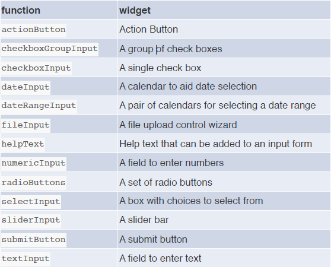

La función para crear un *widget* se coloca dentro del las funciones `*Panel` como `sidebarPanel` o `mainPanel` y consta de dos argumentos:

1. Un **nombre** para el *widget* que es invisible al usuario.
2. Una **etiqueta** que aparecerá con el *widget* en la aplicación.

Por ejemplo, el *widget* Botón de Acción `actionButton("action", label = "Action")` tiene como nombre “action” y como etiqueta “Action”.

Otros argumentos varían dependiendo del *widget*. Para conocer más se puede consultar la [Shiny Widgets Gallery](http://shiny.rstudio.com/gallery/widget-gallery.html).

**Ejemplo:** La app.R en la carpeta Widget-Example.

### Salidas Reactivas

Es posible crear **salidas reactivas** para una aplicación de Shiny, las cuales responden cuando el usuario alterna los valores de un *widget*, en análogía a un interrumplor (que puede tomar más de dos valores).

Se crea en dos pasos:

1. Agregando un objeto de R a la interfaz de usuario `UI`.
2. Indicando a Shiny cómo construir el objeto en la función `server`.

#### Paso 1

Shiny constiene una familia de funciones que transforman objetos de R en salidas de la interfaz de usuario. Cada función crea un tipo específico de salida:

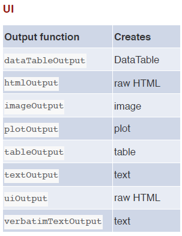

Las funciones de salida se agregan al `UI` dentro de las funciones `*Panel`, al igual que los elementos HTML y los *widgets*.

La función de salida le indica a Shiny dónde colocar el objeto.

Cada función `*Output` requiere de un único argumento, el cual le especifica a Shiny el nombre que utilizará para la salida reactiva y que no es visible al usuario.

**Ejemplo:** La app.R en la carpeta Output-Example.

```r
ui <- fluidPage(
  titlePanel("censusVis"),

  sidebarLayout(
    sidebarPanel(
      helpText("Create demographic maps with
               information from the 2010 US Census."),

      selectInput("var",
                  label = "Choose a variable to display",
                  choices = c("Percent White",
                              "Percent Black",
                              "Percent Hispanic",
                              "Percent Asian"),
                  selected = "Percent White"),

      sliderInput("range",
                  label = "Range of interest:",
                  min = 0, max = 100, value = c(0, 100))
      ),

    mainPanel(
      textOutput("selected_var")
    )
  )
  )
```

#### Paso 2

El siguiente paso es indicarle a Shiny cómo construir el objeto. Esto se realiza mediante código en R dentro de la función `server`, la cual construye un objeto llamado `output`. La función `server` necesita una entrada para cada objeto que construye, la cual se debe definir en los argumentos de entrada de dicha función, en este caso `output`. El nombre debe coincidir con el nombre asignado en la `UI`.

En el siguiente ejemplo, el nombre `output$selected_var` coincide con el argumento de la función de salida `textOutput("selected_var")` del ejemplo anterior:

```r
server <- function(input, output) {

  output$selected_var <- renderText({
    "You have selected this"
  })

}
```

Como vemos en el ejemplo, cada entrada `output` alguna de las siguientes funciones `render*` de acuerdo al tipo de objeto reactivo de salida que se desea:

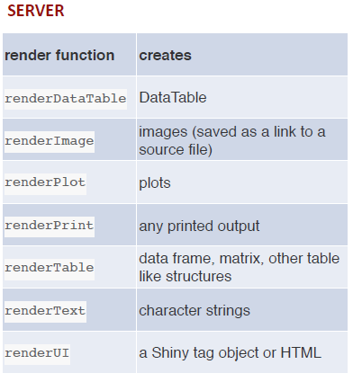

Cada función `render*` toma un sólo argumento: una expresión en R delimitada por llaves `{}`

La última parte de este paso es generar una salida reactiva especificando el argumento `input` de la función `server`. `input` construye un nuevo objeto que hace referencia a alguno de los *widgets* definidos en el `UI` llamando los diferentes valores que puede tomar en el argumento `choices`. El nombre debe coincidir con el nombre asignado en la `UI`.

En el ejemplo anterior, el `UI` contiene dos *widgets* llamados `var` y `range`. El único *widget* que contiene `choices` es `var`, por lo que es el único que generará una salida reactiva:

```r
server <- function(input, output) {

  output$selected_var <- renderText({
    print("You have selected this", input$var)
  })

}
```

**Ejemplo:** La app.R en la carpeta Output-Example.

### Documentos Interactivos

Un **documento interactivo** en R es un archivo R Markdown que contiene *widgets* y salidas de Shiny.

Un archivo R Markdown es útil por sus siguientes características:

- Su sencillez y rapidez de escritura.
- Puede incorporar código de R, lo que crea un reporte reproducible.
- Se puede compilar en un archivo HTML, PDF, WORD, entre otros.

Además, como veremos a continuación, es posible convertir un archivo R Markdown en un documento interactivo en dos pasos:

1. Incluyendo el comando `runtime: shiny` en el encabezado del documento R Markdown.
2. Incluyendo *widgets* y funciones `render*` de Shiny en los *chunks* de código de R.

Debido a que R Markdown provee automáticamente la interfaz gráfica para la aplicación, no es necesario incluir un archivo `UI`.

La paquetería `rmarkdown` compilará el documento en una aplicación reactiva de Shiny, con la apariencia tradicional de un documento de R Markdown pero con componentes reactivos.

#### Paso 1

El comando `runtime: shiny` notifica a la paquetería `rmarkdown` que el archivo contiene componentes de Shiny.

Como el archivo contiene aplicaciones de Shiny es necesario compilarlo a un documento HTML.

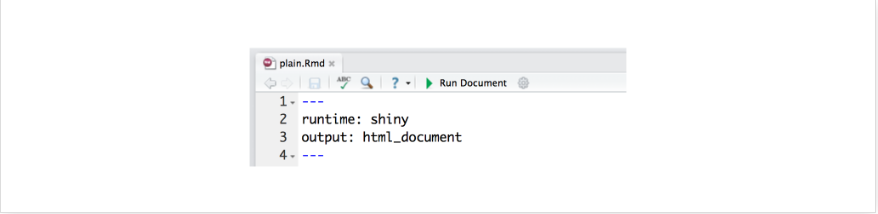

#### Paso 2

Para agregar un *widget* al documento, simplemente se llama a una función *widget* de Shiny dentro de un *chunk* de código de R.

De la misma manera, para agregar salidas reactivas, simplemente se llama una función `render*` de Shiny dentro de un *chunk* de código de R.

**Ejemplo:** Ver documento Int-Doc.Rmd:

## Referencias

- [Shiny Cheat Sheet](https://shiny.rstudio.com/images/shiny-cheatsheet.pdf)
- [Learn Shiny](https://shiny.rstudio.com/tutorial/)